# {decorr} Graph and Spatial Analysis of Iconography for Archaeology

Thomas Huet

# Introduction

# Install

Install the `decorr` package from GitHub and load it

```r
devtools::install_github("zoometh/iconr")
library(decorr)
```

## Contents

**functions**

```r
print(ls("package:decorr"))
```

```
#> [1] "labels.shadow" "plot.dec.grph" "read.eds"      "read.nds"
```

**external data**

```r
doss <- system.file("extdata", package = "decorr")
print(list.files(doss))
```

```
#>  [1] "(Archives)"                        "Cerro_Muriano.Cerro_Muriano_1.jpg"
#>  [3] "edges.dbf"                         "edges.shp"
#>  [5] "edges.shx"                         "edges.tsv"
#>  [7] "imgs.tsv"                          "nodes.dbf"
#>  [9] "nodes.shp"                         "nodes.shx"
#> [11] "nodes.tsv"
```

… you change change `doss` to the path of your working directory

- ‘drawing’: load an image with the `magick` package

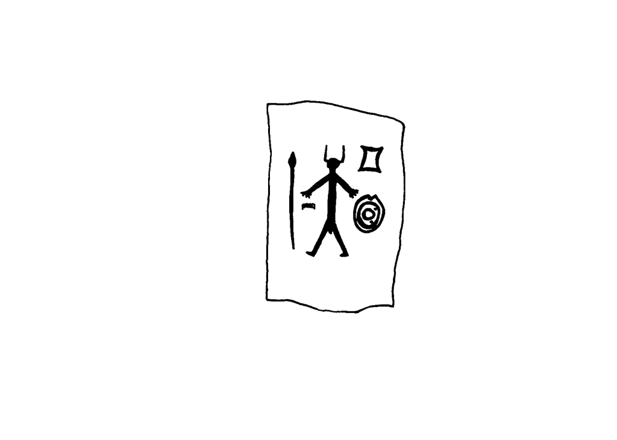

```r
drawing <- magick::image_read(system.file("extdata", "Cerro_Muriano.Cerro_Muriano_1.jpg", package = "decorr"))
plot(drawing)
```

- ‘nodes’: a dataframe or a shapefile of the nodes

```r
doss <- system.file("extdata", package = "decorr")
site <- "Cerro Muriano"
decor <- "Cerro Muriano 1"
nds.df <- read.nds(doss = doss,site = site,decor = decor,nodes = "nodes",dev = ".shp")
kable(nds.df)
```

| site | decor | id | type | x | y |
| --- | --- | --- | --- | --- | --- |
| Cerro Muriano | Cerro Muriano 1 | 1 | personnage | 349.8148 | -298.3244 |
| Cerro Muriano | Cerro Muriano 1 | 2 | casque | 349.8148 | -243.9851 |
| Cerro Muriano | Cerro Muriano 1 | 3 | lance | 238.4637 | -298.3244 |
| Cerro Muriano | Cerro Muriano 1 | 4 | bouclier | 446.0222 | -381.1697 |
| Cerro Muriano | Cerro Muriano 1 | 5 | peigne | 283.0041 | -358.0086 |
| Cerro Muriano | Cerro Muriano 1 | 7 | sexe_masculin | 342.6884 | -427.4917 |
| Cerro Muriano | Cerro Muriano 1 | 8 | lingot_pdb | 451.1489 | -237.4782 |

```r
doss <- system.file("extdata", package = "decorr")
site <- "Cerro Muriano"
decor <- "Cerro Muriano 1"
eds.df <- read.eds(doss = doss,site = site,decor = decor,edges = "edges",dev = ".shp")
kable(eds.df)
```

|  | site | decor | typ | a | b | xa | ya | xb | yb |
| --- | --- | --- | --- | --- | --- | --- | --- | --- | --- |
| 0 | Cerro Muriano | Cerro Muriano 1 | NA | 1 | 8 | 349.8148 | -298.3244 | 451.1489 | -237.4782 |
| 1 | Cerro Muriano | Cerro Muriano 1 | NA | 4 | 8 | 451.1489 | -237.4782 | 446.0222 | -381.1697 |
| 2 | Cerro Muriano | Cerro Muriano 1 | NA | 1 | 4 | 349.8148 | -298.3244 | 446.0222 | -381.1697 |
| 3 | Cerro Muriano | Cerro Muriano 1 | NA | 1 | 5 | 283.0041 | -358.0086 | 349.8148 | -298.3244 |
| 4 | Cerro Muriano | Cerro Muriano 1 | NA | 3 | 5 | 283.0041 | -358.0086 | 238.4637 | -298.3244 |
| 5 | Cerro Muriano | Cerro Muriano 1 | + | 1 | 2 | 349.8148 | -298.3244 | 349.8148 | -243.9851 |
| 6 | Cerro Muriano | Cerro Muriano 1 | + | 1 | 7 | 349.8148 | -298.3244 | 342.6884 | -427.4917 |
| 7 | Cerro Muriano | Cerro Muriano 1 | NA | 3 | 1 | 238.4637 | -298.3244 | 349.8148 | -298.3244 |

- column names
  - `id`: id of the edge (a unique number)
  - `type`: type of the edge (`NA`: normal edge, `+`: node `b` is an attribute of node `a`)
  - `a`: *id* of the first node
  - `b`: *id* of the second node
  - `xa,ya`: coordinates of the first node
  - `xb,yb`: coordinates of the second node

## Tutorial

load nodes, edges and create graph for “type” field

```r
site <- "Cerro Muriano"
decor <- "Cerro Muriano 1"
nds.df <- read.nds(doss = doss,site = site,decor = decor,nodes = "nodes",dev = ".shp")
eds.df <- read.eds(doss = doss,site = site,decor = decor,edges = "edges",dev = ".shp")
img.graph <- plot.dec.grph(nds.df = nds.df,
                           eds.df = eds.df,
                           doss = doss,
                           site = "Cerro Muriano",
                           decor = "Cerro Muriano 1",
                           lbl.txt = "type",
                           shw = c("nodes","edges"))
```

```
#> [1] "nodes" "edges"
```

`img.graph` is a magick-image

```r
class(img.graph)
```

```
#> [1] "magick-image"
```

Plot the geometric graph showing the “type” of the nodes

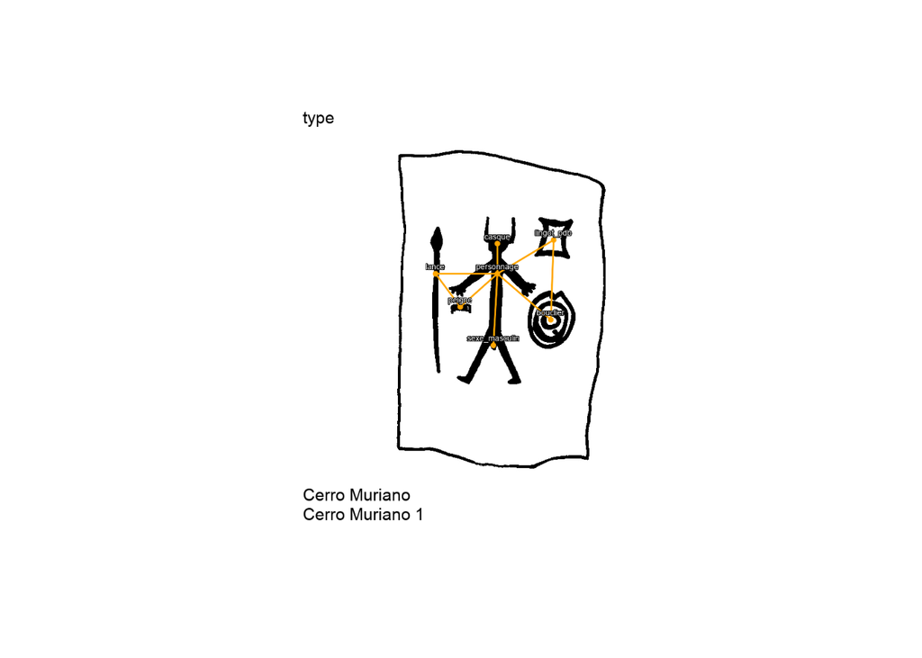

```r
plot(img.graph)
```

## References

Thomas Huet, thomashuet7[at]gmail.com

- Huet, Thomas. “Geometric graphs to study ceramic decoration.” Edited by Mieko Matsumoto and Espen Uleberg. Exploring Oceans of Data, proceedings of the 44th Conference on Computer Applications and Quantitative Methods in Archaeology, CAA 2016. Archaeopress, 2018. 311-324.